# Exercise 6: Places in Text, Places on a Map

Named entity recognition and geocoding in R

Author

Test Student

Published

October 28, 2026

**NoteWhat is this exercise?**

This week’s two readings are about places in printed text. Blevins counted every place name in a Houston newspaper to recover the geography its readers were shown. My paper “An Imagined Geography of Empire” used **named entity recognition (NER)** to do something similar with St. Louis newspapers during the 1904 World’s Fair. In this exercise you’ll do both halves of that work yourself, with two sources you already know:

- **Parts 1–4, *The American City* (1915–1916).** A pre-trained NER model finds the place names in all 24 issues. A **gazetteer** (a list of places with coordinates) turns those names into points, and you map the geography this magazine printed.
- **Parts 5–6, the 1925 Muncie city directory.** You take the addresses you parsed in Exercise 1, send them to the U.S. Census Bureau’s **geocoder**, and map where these people lived.

**This exercise is done at home, on your own.** We won’t meet on Wednesday (10/28), so everything you need is in this file. Run each chunk in order (they’re numbered `# Chunk 1`, `# Chunk 2`, …), read the output, and **write your answers after each `>`**. As always, you’re graded on documented effort, not on mastery. If a chunk gives you an error you can’t fix, copy the error message under the nearest question and keep going.

Budget about 75 minutes. Two chunks need an internet connection (Chunks 7 and 21), and two can take a few minutes the first time you run them (Chunks 9 and 21).

**TipTwo ways to find places in a text**

**Rule-based:** you write down what to look for (a list of names, a pattern like “a number, then a street”) and the computer finds exact matches. This is how the code in Exercise 1 (`E1-DirectoryToDatabase`) transcribed Muncie’s city directory.

**Model-based:** a **model** trained on thousands of sentences that people already labeled guesses which words are names, *including names it has never seen*, from clues like capital letters and the words around them (“in *”, ”Mayor*”). The model we’ll use was trained on Reuters news stories from 1996–1997. It finds four kinds of names: **PER** (people), **LOC** (locations), **ORG** (organizations), and **MISC** (everything else, mostly nationalities and events).

## Setup

This exercise uses three packages you haven’t installed yet. Run this line **once**, in your **console** (not in this file), and answer `n` if R asks about installing from sources:

```r
install.packages(c("nametagger", "tidygeocoder", "maps"))
```

Then run Chunk 1:

```r
# Chunk 1
library(tidyverse)
library(tidytext)       # unnest_tokens()
library(nametagger)     # the NER model
library(maps)           # a list of U.S. cities, and state outlines
library(tidygeocoder)   # sends addresses to the Census geocoder

dir.create("output/exercise6", recursive = TRUE, showWarnings = FALSE)
```

## Part 1: *The American City*, paragraph by paragraph

The first two chunks are the same as in Exercise 5: unzip the 24 issues and read each one into a row.

```r
# Chunk 2
files <- unzip("data/AmericanCity_1915-1916.zip", exdir = tempdir())
```

```r
# Chunk 3
issues <- tibble(file = files) %>%
  mutate(issue = tools::file_path_sans_ext(basename(file)),   # "1915-01_January"
         date  = ym(str_sub(issue, 1, 7)),
         text  = map_chr(file, read_file)) %>%
  select(issue, date, text)

issues
```

| issue | date | text |
| --- | --- | --- |
| 1915-04_April | 1915-04-01 | \n\n\nAPRIL, 1915 Publication Office \n\n\n87 Nassau St., New York \n25 Cents $2.00 a Year \n\n\nAmerican \nCity \n\n\nt \n: \n\n\n} AMonthly Review ofMunicipal Problems and Civic Betterment \n\n\nPOU… |
| 1915-09_September | 1915-09-01 | \n\n87 Nassau Street\nNew York\n\nSEPT., 1915\n\nVolume XIII\nNumber 3\n\nSand-Clay Road Construction*\n\nA Cheap Method of Road Building by Which Many Bad Sand and Clay Sections\nof Country Roads May… |
| 1916-02_February | 1916-02-01 | \n\n\n\n\n\n. 4 \nee \n\n\na a \nru fall i ss , \n\n\n\n\n\nThe upper picture shows some of the unsightly surroundings \nof the State Capitol, Des Moines, lowa, which are being removed \nin carrying o… |
| 1915-06_June | 1915-06-01 | \n\n\nJUNE, 1915 Publication Office \n25 Cents $2.00 a Year Nassau St., New York \n\n\n\n\n\n\n\n\n\n\n\n\n\n\n\n\n\n\n\n\n\n\n\n’ ‘ ' ' : a ee . \nDrowning accidents are bound t ur But hfe can be sav… |
| 1915-02_February | 1915-02-01 | \n\n\n\n\n\n\n\n\nPublication Office \n87 Nassau St., New York \n\n\nFEBRUARY, 1915 \n\n\n25 Cents $2.00 a Year \n\n\n\n\n\n\n\n\n\n\n\n\n\n\n\n\n\n\n\n\n\n\n\n\n\n\n\n\n\nA CITY’S ENTHUSIASM FOR MUNI… |
| 1916-01_January | 1916-01-01 | \n\n\nAmacione \n\n\n” City \n\n\n\n\n\nVOLUME XIV \n\n\nJanuary—June, 1916 \n\n\nee (ale )\\s \n\n\nPUBLISHED BY \n\n\nTHE CIVIC PRESS \n\n\n87 NASSAU STREET, NEW YORK \n\n\n\n\n\n\n\n\nHeler \nRoger… |
| 1915-10_October | 1915-10-01 | \n\n \n \n \n \n \n\n87 Nassau Street\nNew York\n\nOCTOBER, 19-15\n\nVolume x111\nNumber 4\n\nDust Suppression on Suburban and Country\nRoads\n\nBy William H. Connell\n\nChief, Bureau of Highways and … |
| 1916-09_September | 1916-09-01 | ee \n\n\n\| \n\| \n\n\n\n\n\n\n\n\n\n\n\nSeptember \n1916 \n\n\n\n\n\n\n\n\n\n\n\n~ \n\n\nU \n\n\niN \n\n\n\n\n\npus Pertlend ‘Maine Water D \n\n\n\n\n\nistrict \n\n\n— —-- \n\n\n— — \n\n\n35 Cents \n… |
| 1915-11_November | 1915-11-01 | TOWN AND COUNTY EDITION\n\nVol. XIII\nNo. 5\n\n \n\nNovember\n1915\n\nBuilding Up Rural Communities\nBy Willard w. Bartlett\n\nSecretary, Bennington County Vermont Improvement Association\n\nHE origin… |
| 1915-01_January | 1915-01-01 | \n\n\n\n\n\n\n\n\nVOLUME XII \n\n\nJanuary —June, 1915 \n\n\nPUBLISHED BY \n\n\nTHE CIVIC PRESS \n\n\n87 NASSAU STREET, NEW YORK \n\n\n\n\n\nES \n\n\nThe asterisk denotes page-numbers \n\n\n\n\n\nof a… |

[output cut: 14 more lines]

In Exercise 5 we lowercased every word and threw away the punctuation. **For NER we can’t.** Capital letters and periods are some of the model’s best clues. So this time we only do two repairs, both to the OCR text:

- The scanned pages break long words across lines with a hyphen (“Massa-” / “chusetts”). We join those pieces back together.
- The OCR also left invisible “soft hyphens” inside some words. We delete them.

Then we cut each issue at its blank lines. The result is close to one paragraph per row, though OCR sometimes splits a paragraph or glues two together. We drop pieces shorter than five words (page numbers, stray letters).

```r
# Chunk 4
paragraphs <- issues %>%
  mutate(text = str_remove_all(text, "\\x{00AD}")) %>%                    # invisible soft hyphens
  separate_longer_delim(text, delim = regex("\n\\s*\n")) %>%              # cut at blank lines
  mutate(text = str_replace_all(text, "-\\s*\n\\s*", ""),                 # "Massa-\nchusetts" -> "Massachusetts"
         text = str_squish(text)) %>%                                     # remaining line breaks become spaces
  filter(str_count(text, "\\S+") >= 5) %>%
  mutate(paragraph_id = row_number())

nrow(paragraphs)
```

```
[1] 44812
```

Read five random paragraphs. Run the chunk a few times to see different ones.

```r
# Chunk 5
paragraphs %>%
  slice_sample(n = 5) %>%
  pull(text)
```

```
[1] "has opened to the public what is known as"
[2] "‘ . Such an interpretation of eminent domain empowers a city at the pleasure of its officials to transfer property on which is a business plant owned by one individual or corporation to another engaged in the same or another business.”"
[3] "N. S. W.) 1914. Quarto. 136 pp. 109 illustrations. ~ 75 cents"
[4] "occurs. Too much care cannot be exercised in selecting a good engineer."
[5] "public institutions, improvement of parks and waterways—a city administration is judged by the way it protects the homes and the health of"
```

**Q1.** Find two place names in the paragraphs you read, and one place where the OCR split a name. Then explain in your own words why we kept the capital letters this time, when we removed them for topic modeling in Exercise 5.

## Part 2: Run the model

The model needs the input to be one word per line, but each row still needs to be one paragraph. Each paragraph should become one block of text with a word on every line. We can use `\n` to create line breaks inside the same row. Let’s use `unnest_tokens()` to split the paragraphs and create a temporary table with one word per row. This time we use `to_lower = FALSE` and `strip_punct = FALSE` to keep capitalized letters and punctuation.

```r
# Chunk 6-A
ner_input <- paragraphs %>%
  unnest_tokens(term, text, token = "words", to_lower = FALSE, strip_punct = FALSE)

ner_input
```

| issue | date | paragraph_id | term |
| --- | --- | --- | --- |
| 1915-04_April | 1915-04-01 | 1 | 87 |
| 1915-04_April | 1915-04-01 | 1 | Nassau |
| 1915-04_April | 1915-04-01 | 1 | St |
| 1915-04_April | 1915-04-01 | 1 | . |
| 1915-04_April | 1915-04-01 | 1 | , |
| 1915-04_April | 1915-04-01 | 1 | New |
| 1915-04_April | 1915-04-01 | 1 | York |
| 1915-04_April | 1915-04-01 | 1 | 25 |
| 1915-04_April | 1915-04-01 | 1 | Cents |
| 1915-04_April | 1915-04-01 | 1 | $ |

[output cut: 9990 more lines]

The temporary table has 1,638,383 rows, one per word. Before feeding it to the NER model, we need to regroup the words into paragraphs, so our input has one paragraph per row, but with line breaks (`\n`) separating every word.

```r
# Chunk 6-B
ner_input <- ner_input %>%
  group_by(doc_id = issue, sentence_id = paragraph_id) %>%
  summarize(text = str_c(term, collapse = "\n"), .groups = "drop")

ner_input
```

| doc_id | sentence_id | text |
| --- | --- | --- |
| 1915-01_January | 16187 | 87\nNASSAU\nSTREET\n,\nNEW\nYORK |
| 1915-01_January | 16188 | pearing\nin\nthe\nTown\narid\nCounty\nEdition\noly\n. |
| 1915-01_January | 16189 | PAGE\nPAGE\n?\nPAGE\nAdams\n,\nThomas\n.\n.\n.\n213\n,\n334\n,\n379\nFord\n,\nGeorge\nB\n189\nMiller\n,\nB\n.\nF\n.\n,\na\nawtemy\n120\nAubuchon\n,\nTampton\n4o2\nFrancis\n,\nH\n.\nR\n:\n*\n4\nMinium\… |
| 1915-01_January | 16190 | Art\nCommission\n.\n.\n.\n.\n—\nBaths\nand\nSwimming\nPools\n,\nPublic\n.\n.\n. |
| 1915-01_January | 16191 | *\n118\n,\n292\n,\n*\n208\n,\n310\n,\n311\n,\n“\n87\n,\n402\n,\n*\naBo\nBeaches\n,\nBathing\n.\n.\n.\n.\n.\n,\n402\n“\nBefore\nand\nAfter\n”\nPictures\n.\n.\n.\n;\n“\n+\n108\n*\n235\n,\n*\n293\n,\n*\n… |
| 1915-01_January | 16192 | Billboards\nand\nSigns\n.\neRe\nRS\nTe\n.\n6\nawd\nerences\nux\n.\n273 |
| 1915-01_January | 16193 | Bonds\n,\nMunicipal\n.\n.\nA\nRT\n62\n,\n163\n,\n*\n186\n,\n341\n,\n,\n520\n,\n521 |
| 1915-01_January | 16194 | Charities\n,\nPublic\n+\naang\n73\n,\n201\n,\n271\n,\n363\n,\n447\n,\n531 |
| 1915-01_January | 16195 | Charters\n,\nForms\nof\nMunicipal\n.\n.\n.\n.\n*\n6\n,\n163\n,\n184\n*\n377a\n,\n384\n,\n416\n,\n499\n,\n509\n,\n511\n,\n527\n,\n533\n. |
| 1915-01_January | 16196 | RE\na\na\n23\n142\n,\n152\n,\n159\n,\n161\n,\n247\n,\n271\n,\n273\n,\n290\n,\n363\n,\n468\n. |

[output cut: 9990 more lines]

Now let’s load the model. The first time you run Chunk 7 it downloads the English model (trained on the CoNLL-2003 Reuters news data) to a folder outside your repository, so it could take a minute or so. After that it loads the saved copy.

```r
# Chunk 7
model_dir  <- tools::R_user_dir("nametagger", which = "cache")
model_path <- file.path(model_dir, "english-conll-140408.ner")

if (!file.exists(model_path)) {
  dir.create(model_dir, recursive = TRUE, showWarnings = FALSE)
  model <- nametagger_download_model("english-conll-140408", model_dir = model_dir)
} else {
  model <- nametagger_load_model(model_path)
}

example <- ner_input %>%
  filter(str_detect(text, "Brandywine")) %>%
  slice(1)

tagged_example <- predict(model, example)
tagged_example
```

| doc_id | sentence_id | term_id | term | entity |
| --- | --- | --- | --- | --- |
| 1915-04_April | 5 | 1 | MODERN | O |
| 1915-04_April | 5 | 2 | ROADS | O |
| 1915-04_April | 5 | 3 | A | O |
| 1915-04_April | 5 | 4 | Glimpse | O |
| 1915-04_April | 5 | 5 | of | O |
| 1915-04_April | 5 | 6 | the | O |
| 1915-04_April | 5 | 7 | Drive | O |
| 1915-04_April | 5 | 8 | along | O |
| 1915-04_April | 5 | 9 | Brandywine | B-LOC |
| 1915-04_April | 5 | 10 | Creek | I-LOC |

[output cut: 8 more lines]

Scroll through `tagged_example`. Notice that the model returns **one row per word again**. The `entity` column shows the model’s guesses. Possible tags are: `LOC` for locations, `PER` for persons, `ORG` for organizations, and `MISC` for miscellaneous proper names that aren’t any of the above.

**Q2.** This model also uses the **B-/I-/O** code that we’ve seen in class on Monday (10/26). What do `B-LOC` and `I-LOC` mean? What is the `O` code used for?

One word per row isn’t what we want because examples like “New” and “York” should be a single place. The function below walks down the rows and glues each `B-` word to the `I-` words that follow it:

```r
# Chunk 8
tags_to_names <- function(tagged) {
  tagged %>%
    filter(entity != "O") %>% # keep only words inside a name
    mutate(type = str_remove(entity, "^[BI]-"),  # "B-LOC" -> "LOC"
           name_id = cumsum(str_starts(entity, "B-"))) %>%
                    # every B- starts a new name
    group_by(doc_id, sentence_id, name_id, type) %>%
    summarize(name = str_c(term, collapse = " "), .groups = "drop") %>%
    mutate(name = str_replace_all(name, "\\s+([.,;:])", "\\1")) %>%   # "St . Louis" -> "St. Louis"
    select(doc_id, sentence_id, type, name)
}

tags_to_names(tagged_example)
```

| doc_id | sentence_id | type | name |
| --- | --- | --- | --- |
| 1915-04_April | 5 | LOC | Brandywine Creek |
| 1915-04_April | 5 | LOC | Brandywine Park |
| 1915-04_April | 5 | LOC | Wilmington |
| 1915-04_April | 5 | LOC | Delaware |

Now run the model on all 24 issues. This is about 1.6 million words, so it takes a few minutes. The chunk saves the result to `output/exercise6/amcity_entities.csv`, and the next time you run it (or render the file) it reads that file instead of running the model again.

```r
# Chunk 9
entities_file <- "output/exercise6/amcity_entities.csv"

if (!file.exists(entities_file)) {
  entities <- predict(model, ner_input) %>%
    tags_to_names()
  write_csv(entities, entities_file)
}

entities <- read_csv(entities_file, show_col_types = FALSE) %>%
  rename(issue = doc_id, paragraph_id = sentence_id)

entities
```

| issue | paragraph_id | type | name |
| --- | --- | --- | --- |
| 1915-01_January | 16187 | LOC | NASSAU STREET |
| 1915-01_January | 16187 | LOC | NEW YORK |
| 1915-01_January | 16188 | LOC | County Edition |
| 1915-01_January | 16189 | ORG | PAGE PAGE |
| 1915-01_January | 16189 | PER | PAGE Adams |
| 1915-01_January | 16189 | PER | Thomas |
| 1915-01_January | 16189 | ORG | Ford |
| 1915-01_January | 16189 | PER | Aubuchon |
| 1915-01_January | 16189 | PER | Tampton |
| 1915-01_January | 16189 | PER | Francis |

[output cut: 9990 more lines]

## Part 3: What did the model find?

How many names of each type?

```r
# Chunk 10
entities %>%
  count(type, sort = TRUE)
```

| type | n |
| --- | --- |
| ORG | 32220 |
| LOC | 22578 |
| PER | 18031 |
| MISC | 4463 |

The 30 most frequent locations:

```r
# Chunk 11
loc_counts <- entities %>%
  filter(type == "LOC") %>%
  count(name, sort = TRUE, name = "mentions")

loc_counts %>% slice_head(n = 30)
```

| name | mentions |
| --- | --- |
| New York | 860 |
| Ohio | 622 |
| New York City | 582 |
| Chicago | 456 |
| Pa | 450 |
| United States | 412 |
| Philadelphia | 350 |
| Boston | 295 |
| Mass | 218 |
| Pittsburgh | 214 |

[output cut: 20 more lines]

**Q3.** Read the top 30 locations. Which are not cities at all (states, regions, countries)?

The other types are worth a look too:

```r
# Chunk 12
entities %>%
  filter(type %in% c("MISC", "ORG")) %>%
  count(type, name, sort = TRUE) %>%
  group_by(type) %>%
  slice_head(n = 15)
```

| type | name | n |
| --- | --- | --- |
| MISC | American | 293 |
| MISC | AMERICAN CITY | 165 |
| MISC | Mass | 80 |
| MISC | English | 78 |
| MISC | American Crry | 66 |
| MISC | European | 56 |
| MISC | F | 53 |
| MISC | f | 42 |
| MISC | American Ciry | 38 |
| MISC | German | 36 |

[output cut: 20 more lines]

**Q4-A.** Can you spot wrongly tagged entities above?

**Q4-B.** Many MISC names are nationalities or adjectives (“American”, “German”). My paper counted “Brazilian” as a mention of Brazil, because at the St. Louis world’s fair every nationality represented a geographic place. Would that decision make sense for *The American City*? Give one example from your MISC list where lumping a nationality with a place would help, and one where it would mislead.

## Part 4: From names to points: a gazetteer

A name isn’t a location until we give it coordinates. To do that we’ll use a **gazetteer**, a table of place names with their coordinates. The `maps` package in R includes one: `us.cities`, about 1,000 U.S. cities with a population over 40,000, plus all state capitals. But there’s a catch: It’s a *modern* list.

Let’s clean it to match how *The American City* prints names: “Muncie IN” becomes “Muncie”, “WASHINGTON DC” becomes “Washington”, and “Saint Louis” becomes “St. Louis”.

```r
# Chunk 13
us.cities <- us.cities
gazetteer <- us.cities %>%
  mutate(place = str_remove(name, " [A-Z]{2}$"), # drop the state code
         place = if_else(place == str_to_upper(place), str_to_title(place), place),# if the name starts with a captial letter, make it so every word in the name is capitalized, like in titles
         place = str_replace(place, "^Saint ", "St. ")) %>%
  select(place, state = country.etc, pop, lat, long)

gazetteer %>% filter(place %in% c("Muncie", "Washington", "St. Louis"))
```

| place | state | pop | lat | long |
| --- | --- | --- | --- | --- |
| Muncie | IN | 64771 | 40.20 | -85.39 |
| St. Louis | MO | 315546 | 38.64 | -90.24 |
| Washington | DC | 548359 | 38.91 | -77.02 |

Now we can join our location counts to the gazetteer. Some names match more than one city:

```r
# Chunk 14-A
matched <- loc_counts %>%
  inner_join(gazetteer, by = c("name" = "place"), relationship = "many-to-many")

matched %>%
  add_count(name, name = "candidates") %>%
  filter(candidates > 1) %>%
  arrange(desc(mentions), name)
```

| name | mentions | state | pop | lat | long | candidates |
| --- | --- | --- | --- | --- | --- | --- |
| Springfield | 152 | IL | 116725 | 39.78 | -89.64 | 5 |
| Springfield | 152 | MA | 152095 | 42.12 | -72.54 | 5 |
| Springfield | 152 | MO | 150128 | 37.20 | -93.29 | 5 |
| Springfield | 152 | OH | 63915 | 39.93 | -83.80 | 5 |
| Springfield | 152 | OR | 56575 | 44.05 | -122.98 | 5 |
| Newark | 131 | CA | 43018 | 37.52 | -122.03 | 3 |
| Newark | 131 | NJ | 281378 | 40.72 | -74.17 | 3 |
| Newark | 131 | OH | 46870 | 40.07 | -82.42 | 3 |
| Rochester | 123 | MN | 98227 | 44.01 | -92.48 | 2 |
| Rochester | 123 | NY | 209587 | 43.17 | -77.62 | 2 |

[output cut: 97 more lines]

Pick one ambiguous name from this table (Springfield, Portland, Columbus…). Find one paragraph where it appears.

```r
# Chunk 14-B
#| eval: false
paragraphs %>%
  filter(str_detect(text, "Springfield")) %>%
  pull(text) %>%
  head(n = 15)
```

```
 [1] "Stearns Bidg., Springfield, Mass. Woolworth Bidg., New York"
 [2] "Secretary, Hampden County Improvement League, Springfield, Mass."
 [3] "ich largely look to Springfield"
 [4] "irme ire becoming endous a v ( tores at 60 cents per dozer thusiastic in this work he ire comin ent e whole day and traveled 25 miles the office in Springfield at the rate of 3 , =i Vhat can a man do onth fe onference hey are iki ich tremendous demands upon the me: he League made investigation…
 [5] "As a result of the interest created among the big business men of Springfield in this kind of work, there has been organized"
 [6] "what is known as the Eastern States Agri cultural and Industrial Exposition Chis, too, was started by the Springfield Board of lrade. This exposition has purchased 122 acres of land within twenty minutes’ walk of the Springfield Post Office. The trans portation facilities are of the very best.…
 [7] "The exposition will conduct a sales market, where the blue ribbon stock from the eastern and many of the western states will find an excellent market. Already the National Dairy Show and the International Live Stock Exposition are considering Springfield as an eastern branch of their great ins…
 [8] "Springfield, Mass.—Springfield Board of Trade News. Published monthly."
 [9] "SPRINGFIELD, Mo.—In order to get the business interests of Springfield, Mo., better acquainted with the manufacturing enter prises of the city, the Springfield Club set aside Tuesday of each week for two months for visiting the various plants. The membership of the club met at noonday lunch an…
[10] "“See Springfield, Missouri, First’’ was a popular slogan that made for two invaluable business assets: knowing one’s own city better and getting the business men better acquainted with each other"
[11] "The Everwear Manufacturing Company Springfield, Ohio"
[12] "The American Seeding-Machine Co., Inc., Springfield, 0."
[13] "DEPTS. BLOODGOOD NURSERIES F. & F. NURSERIES Flushing, N.Y Springfield, N. J."
[14] "The Baker Mfg. Co., 503 Stanford Ave., Springfield, III."
[15] "The special charter investigating committee visited the cities of Des Moines, 1a.. Memphis, Tenn., and Dayton and Springfield, Ohio. the first two of which have the"
```

**Q5.** Which city does the magazine mean, and how did you tell? Go back to our reading for Monday’s class. How did Cameron Blevins decide which “Washington” or “Springfield” a Houston newspaper meant?

We need some rule for the ambiguous names. Here’s a common and blunt one: pick the place with the largest population. This rule is a guess. It assumes the biggest city is the one people most likely meant. That’s often reasonable, but here it’s problematic for two reasons:

1. the populations in `us.cities` are modern, not 1915 figures;
2. the magazine may well have meant Springfield, IL (the state capital) or Springfield, OH.

We’ll still go with it for now:

```r
# Chunk 15-A
places <- matched %>%
  group_by(name) %>%
  slice_max(pop, n = 1, with_ties = FALSE) %>%  # the blunt rule
  ungroup()
places
```

| name | mentions | state | pop | lat | long |
| --- | --- | --- | --- | --- | --- |
| Abilene | 3 | TX | 113888 | 32.45 | -99.74 |
| Akron | 78 | OH | 206634 | 41.08 | -81.52 |
| Alameda | 4 | CA | 70069 | 37.77 | -122.26 |
| Albany | 47 | NY | 93576 | 42.67 | -73.80 |
| Alexandria | 4 | VA | 127159 | 38.82 | -77.09 |
| Alhambra | 5 | CA | 88857 | 34.08 | -118.13 |
| Allentown | 8 | PA | 105224 | 40.60 | -75.48 |
| Altoona | 8 | PA | 46442 | 40.51 | -78.40 |
| Amarillo | 9 | TX | 183295 | 35.20 | -101.82 |
| Ames | 6 | IA | 57683 | 42.02 | -93.63 |

[output cut: 378 more lines]

Now let’s look at the names that didn’t match anything:

```r
# Chunk 15-B
unmatched_places <- loc_counts %>%
  anti_join(gazetteer, by = c("name" = "place"))
unmatched_places %>% slice_head(n = 30)
```

| name | mentions |
| --- | --- |
| Ohio | 622 |
| New York City | 582 |
| Pa | 450 |
| United States | 412 |
| Mass | 218 |
| Ill | 195 |
| America | 160 |
| Mich | 128 |
| OHIO | 118 |
| Wis | 117 |

[output cut: 20 more lines]

Now let’s compare. How many place names mentioned in the magazine were we able to attach coordinates to?

```r
# Chunk 15-C
sum(places$mentions) / sum(loc_counts$mentions)
```

```
[1] 0.332669
```

```r
# share of LOC mentions we can map
```

Using `us.cities`, we were only able to attach coordinates to around 33% of the place mentions in the magazine. This share represents how much of the magazine’s geography this specific gazetteer can map.

**Q6.** What kinds of places does a modern list of big cities miss in a 1915 magazine?

Now let’s map it. Each point is a city, and its size shows how many times the magazine named it:

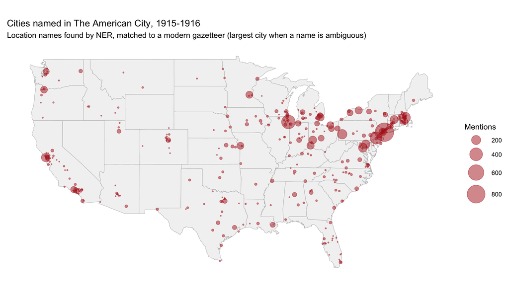

```r
# Chunk 16-A
us_states <- map_data("state")

ggplot() +
  geom_polygon(data = us_states, aes(x = long, y = lat, group = group),
               fill = "grey95", color = "grey70", linewidth = 0.2) +
  geom_point(data = places, aes(x = long, y = lat, size = mentions),
             alpha = 0.5, color = "firebrick") +
  coord_quickmap(xlim = c(-125, -66), ylim = c(24, 50)) +
  scale_size_area(max_size = 12) +
  labs(title = "Cities named in The American City, 1915-1916",
       subtitle = "Location names found by NER, matched to a modern gazetteer (largest city when a name is ambiguous)",
       x = NULL, y = NULL, size = "Mentions") +
  theme_void() +
  theme(plot.margin = margin(10, 10, 10, 10))
```

```r
# Chunk 16-B
# save your outputs
ggsave("output/exercise6/amcity_places_map.png", width = 10, height = 6, bg = "white")
write_csv(places, "output/exercise6/amcity_places.csv")
```

**Q7.** Describe the geography on your map. Where is it dense, where is it empty? *The American City* was published in New York for city officials across the country: how much of what you see is the magazine’s readership, and how much is where it was made (the masthead, its advertisers’ addresses)? Compare with Blevins’s finding about Houston: does this look like a national geography or a regional one?

## Part 5: Muncie, 1925: names in a directory

The next chunk is the parsing code from Data Exercise 1 (`E1-DirectoryToDatabase`), which turns pages 200–214 of the 1925 Muncie City Directory into one row per entry.

**Show the Exercise 1 code**

```r
# Chunk 17
pages <- read_csv("data/citydir-1925-sample.csv", show_col_types = FALSE)

lines <- pages %>%
  separate_longer_delim(text, delim = "\n") %>%
  rename(line = text) %>%
  mutate(line = str_squish(line)) %>%
  filter(line != "") %>%
  mutate(line = str_remove(line, "^(([^A-Za-z0-9\\s.*]\\S*|\\S*[^A-Za-z0-9\\s.*]\\S*|[a-z](\\.[a-z])?|\\d)\\s)+(?=\\*?[A-Z][a-z'-]+ (Mrs\\. )?[A-Z].*\\b(res|rooms|bds)\\b)"))
# NEW in E6: delete OCR margin junk ("~", "::C", "u") in front of an entry. We didn't catch these in E1

entries <- lines %>%
  mutate(entry_id = cumsum(str_detect(line, "^\\*?\\s?[A-Z][a-z'-]+ (Mrs\\. )?[A-Z]"))) %>%
  group_by(pagetitle, entry_id) %>%
  summarize(entry = str_c(line, collapse = " "), .groups = "drop") %>%
  mutate(entry = str_replace_all(entry, "-\\s", ""))

name_pattern <- "^\\*?\\s?[A-Z][a-z'-]+(\\s(Mrs\\.|[A-Z][A-Za-z]*\\.?|jr\\.))*(\\s\\([^)]*\\))?,?"

by_machine <- entries %>%
  mutate(
    asterisk   = str_detect(entry, "^\\*"),
    name       = str_extract(entry, name_pattern) %>% str_remove("^\\*\\s?") %>% str_remove(",$") %>% str_squish(),
    surname    = word(name, 1),
    given      = str_remove(name, "^\\S+\\s?") %>% str_remove("\\s?\\(.*$"),
    spouse     = str_match(name, "\\(([^)]+)\\)")[, 2],
    rest       = str_remove(entry, name_pattern) %>% str_squish(),
    occupation = str_extract(rest, "^(?!res\\b|rooms\\b|bds\\b)[a-z][^,]*?(?=,|\\s(res|rooms|bds)\\b|$)"),
    housing    = str_match(entry, "\\b(res|rooms|bds)\\b")[, 2],
    address    = str_match(entry, "\\b(?:res|rooms|bds)\\b\\.?,?\\s+(.+)$")[, 2]
  ) %>%
  select(pagetitle, entry_id, entry, asterisk, surname, given, spouse, occupation, housing, address)

by_machine
```

| pagetitle | entry_id | entry | asterisk | surname | given | spouse | occupation | housing | address |
| --- | --- | --- | --- | --- | --- | --- | --- | --- | --- |
| Page 200 | 0 | . 0 u ~ z -I > 1, j\\ I 11 <( I ~ CJ z w llJ ~ <( ~ <( ....J llJ 0 A .MERICAN LA:UNDRY BEST SERVICE LAUNDRY 196 MUNCIE :-: [CUR] BEST WORK Phone 909 DIRECTORY | FALSE | NA | NA | NA | NA | NA | NA |
| Page 200 | 1 | Cunningham Wm. W. (Lorana), paper worker, res. 1426 S. Liberty | FALSE | Cunningham | Wm. W. | Lorana | paper worker | res | 1426 S. Liberty |
| Page 200 | 2 | Cunningham Wm. W. jr. laborer, res. 1426 S. Liberty m" See also '' Conning ham'' and '' Cottingham'' | FALSE | Cunningham | Wm. W. jr. | NA | laborer | res | 1426 S. Liberty m" See also '' Conning ham'' and '' Cottingham'' |
| Page 200 | 3 | Cunnington Annie Mary, res. 316 W. Adams | FALSE | Cunnington | Annie Mary | NA | NA | res | 316 W. Adams |
| Page 200 | 4 | Cunnington Chas. laborer, res. 2215 S. Elm | FALSE | Cunnington | Chas. | NA | laborer | res | 2215 S. Elm |
| Page 200 | 5 | Cunnington Chas. E. (Ruth M.), manager, res. 15 Bellaire Av | FALSE | Cunnington | Chas. E. | Ruth M. | manager | res | 15 Bellaire Av |
| Page 200 | 6 | Cunnington David (Rachel), laborer, res. 2215 S. Elm | FALSE | Cunnington | David | Rachel | laborer | res | 2215 S. Elm |
| Page 200 | 7 | Cunnington Jonathan (Fern M.), salesman, 429 E. 12th, res. R.F.D. 6 • | FALSE | Cunnington | Jonathan | Fern M. | salesman | res | R.F.D. 6 • |
| Page 200 | 8 | Cunnington Mary E. vvidow of Richard, res. 316 W. Adams | FALSE | Cunnington | Mary E. | NA | vvidow of Richard | res | 316 W. Adams |
| Page 200 | 9 | Cunnington Richard J. (Lola), laborer, res. 324 W. 5th | FALSE | Cunnington | Richard J. | Lola | laborer | res | 324 W. 5th |

[output cut: 454 more lines]

In Exercise 1, you found names and employers in two ways: by hand, reading the scans (Part 2), and with a set of rules written as regular expressions (Part 3). Those rules pulled out names, occupations, and addresses, but not employers. What does the NER model find in the same entries? Let’s use `tags_to_names()` from Chunk 8:

```r
# Chunk 18-A
directory_names <- by_machine %>%
  mutate(entry = str_remove_all(entry, "\\x{00AD}")) %>%            # soft hyphens again
  unnest_tokens(term, entry, token = "words", to_lower = FALSE, strip_punct = FALSE) %>%
  group_by(doc_id = pagetitle, sentence_id = entry_id) %>%
  summarize(text = str_c(term, collapse = "\n"), .groups = "drop") %>%
  predict(model, .) %>%
  tags_to_names()

directory_names %>% count(type, sort = TRUE)
```

| type | n |
| --- | --- |
| PER | 798 |
| ORG | 323 |
| LOC | 117 |
| MISC | 19 |

```r
# Chunk 18-B
directory_names %>%
  filter(type == "ORG") %>%
  count(name, sort = TRUE)
```

| name | n |
| --- | --- |
| MUNCIE | 13 |
| University Av | 12 |
| Macedonia Av | 7 |
| Ohio Av | 5 |
| Plum | 5 |
| S | 5 |
| Sons | 3 |
| Warner Gear Co | 3 |
| Av | 2 |
| B.D | 2 |

[output cut: 251 more lines]

**Q8-A.** Look at the `ORG` list above. Which employers did the model find, and what did it get wrong? Find at least three examples of mislabeled entities and three examples of correctly identified organizations.

**Q8-B.** Then think back to Exercise 1: for a city directory, would you rather use your own hand transcription (like you did in E1, Part 2), or this pre-trained NER model?

## Part 6: Geocoding Muncie

**Geocoding** turns an address into coordinates. The Census Bureau’s geocoder is free, needs no account, and knows every street address range in today’s United States. But as always, there’s a catch: It doesn’t know 1925 addresses.

So, before sending anything, the addresses need work. Here are the decisions this chunk makes, one per line:

1. Repair OCR: soft hyphens, “Madi-son”, “S . Plum”, “A.v”, stray periods, and street numbers split by spaces (“27 09” becomes “2709”).
2. Keep only what looks like *number + (direction) + street name + (Av)*. “Same” and “R. F. D. 6” (a rural mail route) can’t be geocoded, so they drop out, along with anything the OCR broke too badly to read.
3. Drop the “½” (half-numbers like 510½ were usually upstairs or rear units), and write “2d” and “3d” as “2nd” and “3rd”.
4. The directory prints “Av” for avenues and **no type at all** for most other streets. We assume those are streets and add “St”.

```r
# Chunk 19
addresses <- by_machine %>%
  filter(!is.na(address)) %>%
  mutate(
    work_address = str_match(entry, "(\\d+\\S*\\s[^,]*?)\\.?,?\\s+(?:res|rooms|bds)\\b\\.?\\s+same\\b")[, 2],
    # "res. same" = lives at the business address printed just before
    address = if_else(str_detect(address, "^same\\b") & !is.na(work_address), work_address, address)
    ) %>%
  mutate(
      clean = address %>%
      str_remove_all("\\x{00AD}") %>%
      # remove soft hyphens (invisible OCR hyphens)
      str_replace_all("(?<=\\s)[^A-Za-z0-9\\s.\\x{00BD}]+(?=\\s)", "") %>% str_squish() %>%
        # remove stray symbols between words ("301 ~ E. Seymour")
      str_replace_all("(?<=[a-z])-(?=[a-z])", "") %>%
      # Madi-son -> Madison
      str_replace_all("\\s+\\.", ".") %>%
      # S . Plum -> S. Plum
      str_replace_all("A\\.v\\b", "Av") %>%
      # A.v -> Av
      str_remove("^[.\\s]+") %>%
      # remove stray leading periods
      str_replace("^(\\d+) (\\d+) (\\d+)(?=\\s)", "\\1\\2\\3") %>%
      # 2 11 9 -> 2119
      str_replace("^(\\d+) (\\d+)(?=\\s)", "\\1\\2"),
      # 27 09 -> 2709
    street = str_extract(clean, "^\\d+\\s?\\x{00BD}?\\s([NSEW]\\.?\\s)?[A-Z0-9][A-Za-z0-9]+(\\sAv\\b)?"),
      # pull every street address and ignore what comes after
    street = street %>%
      str_remove("\\s?\\x{00BD}") %>%
      # 510½ -> 510
      str_replace("\\b2d\\b", "2nd") %>%
      # 2d -> 2nd
      str_replace("\\b3d\\b", "3rd") %>%
      # 3d -> 3rd
      str_replace("\\sAv$", " Ave"),
      # Av -> Ave
    street = if_else(str_detect(street, "Ave$"), street, str_c(street, " St"))
    # keep addresses with "Ave" as is; add "St" to those without "Ave"
  )

addresses %>% select(street, address)
```

| street | address |
| --- | --- |
| 1426 S. Liberty St | 1426 S. Liberty |
| 1426 S. Liberty St | 1426 S. Liberty m" See also '' Conning ham'' and '' Cottingham'' |
| 316 W. Adams St | 316 W. Adams |
| 2215 S. Elm St | 2215 S. Elm |
| 15 Bellaire Ave | 15 Bellaire Av |
| 2215 S. Elm St | 2215 S. Elm |
| NA | R.F.D. 6 • |
| 316 W. Adams St | 316 W. Adams |
| 324 W. 5th St | 324 W. 5th |
| NA | R. F. D. 6 0 Cunnington Wm. J. cashier, American Railway Express Co . LO res. R. F. D. 7 |

[output cut: 398 more lines]

Which addresses did we lose before the geocoder even sees them?

```r
# Chunk 20-A
addresses %>% filter(is.na(street)) %>% select(entry, address)
```

| entry | address |
| --- | --- |
| Cunnington Jonathan (Fern M.), salesman, 429 E. 12th, res. R.F.D. 6 • | R.F.D. 6 • |
| Cunnington Samuel L. grocery, 429 E. 12th, res. R. F. D. 6 0 Cunnington Wm. J. cashier, American Railway Express Co . LO res. R. F. D. 7 | R. F. D. 6 0 Cunnington Wm. J. cashier, American Railway Express Co . LO res. R. F. D. 7 |
| Current Ruby G. telephone operator, Warner Gear Co. res . o::: R. F. D. 9 | . o::: R. F. D. 9 |
| Curtis Chas. res. 2421 S. P l um | 2421 S. P l um |
| Curtis Geo . B . president, 'rl1e Miller Shoe Co. 311 S. Walnut, res. East St. Louis CURTIS & GUBBINS, ( Ernest M. C. & John F. G.), Street and Road Con tractors ; also Proprieto rs City Coal Yards, O… | East St. Louis CURTIS & GUBBINS, ( Ernest M. C. & John F. G.), Street and Road Con tractors ; also Proprieto rs City Coal Yards, Office and Yards, 606 S. Elm, Phone 313 |
| Curtis J as. res. 2421 S. P lum | 2421 S. P lum |
| Curtis John, res. 242 1 S. P lum | 242 1 S. P lum |
| Curtis John P . res. 225 N. D ill | 225 N. D ill |
| Curtis Wm. ( Maude B . ), rooms 221 K il gore Av | 221 K il gore Av |
| Dague Harold L. (M. L. D. & Sons), res. R. F. D. 6 DAGUE M. L. & SONS, (Michael L., Harold L. & Arthur G.), Coal and Builders' Supplies, 400 Kirby Av | R. F. D. 6 DAGUE M. L. & SONS, (Michael L., Harold L. & Arthur G.), Coal and Builders' Supplies, 400 Kirby Av |

[output cut: 36 more lines]

**Q9.** Look at the addresses Chunk 20-A dropped. Pick two or three of them and say what kind of place each one is (a hotel? another town? a garbled OCR line?). Do you think the people we lose at this step are a random sample of the directory, or are some kinds of people more likely to disappear? Explain in two or three sentences.

Now, let’s pass the addresses we have to the U.S. Census geocoder. Chunk 21 sends all the distinct addresses to the Census Bureau in one batch and saves the answer with latitude and longitude values, so you only send them once.

First, how many unique addresses are we sending to the geocoder?

```r
# Chunk 20-B
addresses_distinct <- addresses %>%
  filter(!is.na(street)) %>%
  distinct(street)

nrow(addresses_distinct) # how many unique addresses we'll send
```

```
[1] 278
```

**WarningIf the Census geocoder doesn’t answer**

Government servers sometimes go down. If Chunk 21 gives you an error, run this line in your **console** and then run Chunk 21 again. It copies a version I geocoded with this exact code:

`file.copy("data/muncie-1925-geocoded.csv", "output/exercise6/muncie_geocoded.csv")`

```r
# Chunk 21
geo_file <- "output/exercise6/muncie_geocoded.csv"

if (!file.exists(geo_file)) {
  geocoded <- addresses_distinct %>%
    mutate(city = "Muncie", state = "IN") %>%
    geocode(street = street, city = city, state = state,
            method = "census", mode = "batch", full_results = TRUE)
  write_csv(geocoded, geo_file)
}

geocoded <- read_csv(geo_file, show_col_types = FALSE)
```

The Census geocoder reports two things for every address. `match_indicator` says whether it found the address (`Match`, `No_Match`, or `Tie` when two places fit equally well). `match_type` says whether the match was `Exact` or `Non_Exact`, meaning it had to change something:

```r
# Chunk 22
geocoded %>%
  count(match_indicator, match_type) %>%
  mutate(share = round(n / sum(n), 2))
```

| match_indicator | match_type | n | share |
| --- | --- | --- | --- |
| Match | Exact | 180 | 0.65 |
| Match | Non_Exact | 52 | 0.19 |
| No_Match | NA | 39 | 0.14 |
| Tie | NA | 7 | 0.03 |

A match isn’t necessarily a correct match. Compare what we sent with what the geocoder says it found:

```r
# Chunk 23
geocoded %>%
  filter(match_indicator == "Match") %>%
  select(street, matched_address, match_type) %>%
  arrange(match_type)
```

| street | matched_address | match_type |
| --- | --- | --- |
| 1426 S. Liberty St | 1426 S LIBERTY ST, MUNCIE, IN, 47302 | Exact |
| 316 W. Adams St | 316 W ADAMS ST, MUNCIE, IN, 47305 | Exact |
| 2215 S. Elm St | 2215 S ELM ST, MUNCIE, IN, 47302 | Exact |
| 324 W. 5th St | 324 W 5TH ST, MUNCIE, IN, 47302 | Exact |
| 1200 E. 8th St | 1200 E 8TH ST, MUNCIE, IN, 47302 | Exact |
| 915 S. Beacon St | 915 S BEACON ST, MUNCIE, IN, 47302 | Exact |
| 516 E. Washington St | 516 E WASHINGTON ST, MUNCIE, IN, 47305 | Exact |
| 2011 S. Madison St | 2011 S MADISON ST, MUNCIE, IN, 47302 | Exact |
| 712 E. 7th St | 712 E 7TH ST, MUNCIE, IN, 47302 | Exact |
| 712 E. Willard St | 712 E WILLARD ST, MUNCIE, IN, 47302 | Exact |

[output cut: 222 more lines]

**Q10.** Muncie has renamed and renumbered streets since 1925, and some 1925 blocks no longer exist. How could you check whether “1300 Butler St” in 1925 is the same spot as 1300 Butler St today? (Name a source, not a method in R.)

Last step: join the coordinates back to the **people**, map them, and save the addresses that failed for our GIS lab visit next week. Each point is one directory entry. Orange points are entries the publisher marked with an asterisk.

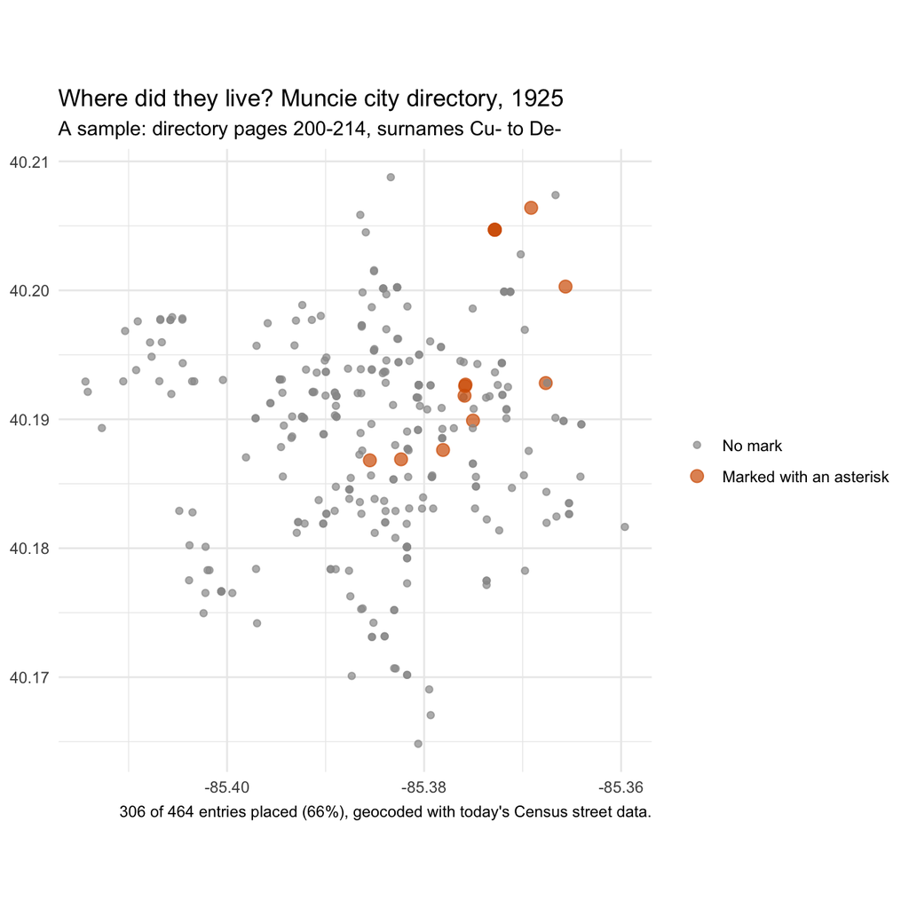

```r
# Chunk 24-A
residents <- addresses %>%
  left_join(geocoded %>% select(street, lat, long, match_indicator, match_type, matched_address),
            by = "street")

muncie <- residents %>%
  filter(between(lat, 40.10, 40.30), between(long, -85.50, -85.25))   # drop matches outside Muncie

match_rate <- round(100 * nrow(muncie) / nrow(by_machine))

ggplot(muncie, aes(x = long, y = lat)) +
  geom_point(aes(color = asterisk, size = asterisk), alpha = 0.7) +
  scale_color_manual(values = c(`FALSE` = "grey60", `TRUE` = "#D55E00"),
                     labels = c("No mark", "Marked with an asterisk")) +
  scale_size_manual(values = c(`FALSE` = 1.5, `TRUE` = 3),
                    labels = c("No mark", "Marked with an asterisk")) +
  coord_quickmap() +
  labs(title = "Where did they live? Muncie city directory, 1925",
       subtitle = "A sample: directory pages 200-214, surnames Cu- to De-",
       caption = str_glue("{nrow(muncie)} of {nrow(by_machine)} entries placed ({match_rate}%), geocoded with today's Census street data."),
       x = NULL, y = NULL, color = NULL, size = NULL) +
  theme_minimal()
```

```r
# Chunk 24-B
# save your outputs
ggsave("output/exercise6/muncie_1925_map.png", width = 7, height = 7, bg = "white")

residents %>%
  filter(is.na(lat)) %>%
  select(entry, address, street) %>%
  write_csv("output/exercise6/unmatched.csv")
```

**Q11.** The map has no streets, river, or rail lines. What would you need to add before it could say anything about 1925 Muncie? Then go back to your answer to the last question of Exercise 1. Now that you’ve actually mapped the asterisk, what should a responsible version of this map include or explain before anyone sees it?

## Save, Commit, Push

Render this file. Rendering re-uses the saved model results and geocoding results in `output/exercise6/`, so it only takes a minute. Then, in GitHub Desktop, commit this file, the `.html`, and the `output/exercise6/` folder with a message like “Exercise 6: NER and geocoding,” and **Push origin**.

**TipSources**

- *The American City*, vols. 12–15 (New York: The Civic Press, 1915–1916), OCR text from digitized copies.
- *Muncie City Directory, 1925–26*, pages 200–214, Ball State University Digital Media Repository.
- Cameron Blevins, “Space, Nation, and the Triumph of Region: A View of the World from Houston,” *Journal of American History* 101, no. 1 (2014): 122–147.
- Luc Avelar, “An Imagined Geography of Empire,” 2023.
- Jana Straková, Milan Straka, and Jan Hajič, NameTag, Institute of Formal and Applied Linguistics, Charles University. English model `english-conll-140408`, trained on the CoNLL-2003 data (CC BY-NC-SA). R package `nametagger` by Jan Wijffels.
- U.S. Census Bureau Geocoder, through the R package `tidygeocoder` by Jesse Cambon et al.
- `us.cities` and state outlines from the R package `maps`.